written by ideajoon  
※ 참고 : 딥 러닝을 이용한 자연어 처리 입문 (https://wikidocs.net/book/2155) 자료를 공부하고 정리함

# 07. 머신 러닝(Machine Learning) 개요

## 목차

1. 머신 러닝이란(What is Machine Learning?)
2. 머신 러닝 훑어보기
3. 선형 회귀(Linear Regression)
4. 로지스틱 회귀(Logistic Regression) - 이진 분류
5. 다중 입력에 대한 실습
6. 벡터와 행렬 연산
7. 소프트맥스 회귀(Softmax Regression) - 다중 클래스 분류

## 1. 머신 러닝이란(What is Machine Learning?)

### 1) 머신 러닝(Machine Learning)이 아닌 접근 방법의 한계

### 2) 머신 러닝은 기존 프로그래밍의 한계에 대한 해결책이 될 수 있다

## 2. 머신 러닝 훑어보기

### 1) 머신 러닝 모델의 평가

[figure not shown]

검증용 데이터는 모델의 성능을 평가하기 위한 용도가 아니라, 모델의 성능을 조정하기 위한 용도입니다. 더 정확히는 과적합이 되고 있는지 판단하거나 하이퍼파라미터의 조정을 위한 용도입니다.

가중치와 편향과 같은 학습을 통해 바뀌어져가는 변수를 이 책에서는 매개변수라고 부릅니다.

하이퍼파라미터는 보통 사용자가 직접 정해줄 수 있는 변수라는 점입니다.  
경사 하강법에서 학습률(learning rate)이 이에 해당되며 딥 러닝에서는 은닉층의 수, 뉴런의 수, 드롭아웃 비율 등이 이에 해당됩니다.

매개변수는 사용자가 결정해주는 값이 아니라 모델이 학습하는 과정에서 얻어지는 값입니다.

만약, 검증 데이터와 테스트 데이터를 나눌 만큼 데이터가 충분하지 않다면 k-폴드 교차 검증이라는 또 다른 방법을 사용하기도 합니다.

### 2) 분류(Classification)와 회귀(Regression)

1. 분류(Classification)
   - 이진 분류(Binary Classification)
   - 다중 클래스 분류(Multi-Class Classification)
   - 다중 레이블 분류(Multi-lable Classification)
2. 회귀(Regression)
   - 선형 회귀(Lineare Regression)
   - 로지스틱 회귀(Logistic Rgression)

회귀 문제는 분류 문제처럼 0 또는 1이나 과학 책장, IT 책장 등과 같이 분리된(비연속적인) 답이 결과가 아니라 연속된 값을 결과로 가집니다. 예를 들어 시험 성적을 예측하는데 5시간 공부하였을 때 80점, 5시간 1분 공부하였을 때는 80.5점, 7시간 공부하였을 때는 90점 등이 나오는 것과 같은 문제가 있습니다. 그 외에도 시계열 데이터를 이용한 주가 예측, 생산량 예측, 지수 예측 등이 이에 속합니다.

### 3) 지도 학습(Supervised Learning)과 비지도 학습(Unsupervised Learning)

#### (1) 지도 학습

지도 학습이란 레이블(Label)이라는 정답과 함께 학습하는 것을 말합니다.

#### (2) 비지도 학습

비지도 학습은 레이블이 없이 학습하는 것을 말합니다.

예를 들어 토픽 모델링의 LDA는 비지도 학습에 속하며, 뒤에서 배우게 되는 워드투벡터(Word2Vec)는 마치 지도 학습을 닮았지만, 비지도 학습에 속합니다.

### 4) 샘플(Sample)과 특성(Feature)

[figure not shown]

### 5) 혼동 행렬(Confusion Matrix)

혼동 행렬(Confusion Matrix)

| 구분 | 참(Positive) | 거짓(Negative) |
| --- | --- | --- |
| 참 | TP | FN |
| 거짓 | FP | TN |

이를 각각 TP(True Positive), TN(True Negative), FP(False Postivie), FN(False Negative)라고 하는데 True는 정답을 맞춘 경우고 False는 정답을 맞추지 못한 경우입니다.

그리고 Positive와 Negative는 각각 제시했던 정답입니다.

즉, TP는 양성(Postive)이라고 대답하였고 실제로 양성이라서 정답을 맞춘 경우입니다. TN은 음성(Negative)이라고 대답하였는데 실제로 음성이라서 정답을 맞춘 경우입니다.

#### (1) 정밀도(Precision)

정밀도은 양성이라고 대답한 전체 케이스에 대한 TP의 비율입니다.

$정밀도 = \frac{TP}{TP + FP}$

#### (2) 재현률(Recall)

재현률은 실제값이 양성인 데이터의 전체 개수에 대해서 TP의 비율입니다. 즉, 양성인 데이터 중에서 얼마나 양성인지를 예측(재현)했는지를 나타냅니다.

$재현률 = \frac{TP}{TP + FN}$

### 6) 과적합(Overfitting)과 과소 적합(Underfitting)

- 과적합(Overfitting)

과적합(Overfitting)이란 훈련 데이터를 과하게 학습한 경우를 말합니다.

[figure not shown]

스팸 메일 분류하기 실습에서 훈련 데이터에 대한 훈련 횟수를 30회로 주어서 의도적으로 과적합을 발생시켰을 때의 그래프입니다.

X축의 에포크(epoch)는 전체 훈련 데이터에 대한 훈련 횟수를 의미합니다.

스팸 메일 분류하기 실습은 에포크가 3~4를 넘어가게 되면 과적합이 발생합니다.

- 과소적합(Underfitting)

테스트 데이터의 성능이 올라갈 여지가 있음에도 훈련을 덜 한 상태를 반대로 과소적합(Underfitting)이라고 합니다.

과소 적합은 훈련 자체가 부족한 상태이므로 과대 적합과는 달리 훈련 데이터에 대해서도 보통 정확도가 낮다는 특징이 있습니다.

딥 러닝을 할 때는 과적합을 막을 수 있는 드롭 아웃(Drop out), 조기 종료(Early Stopping)과 같은 몇 가지 방법이 존재

## 3. 선형 회귀(Linear Regression)

### 1) 선형 회귀(Linear Regression)

만약, 독립 변수 x가 1개라면 단순 선형 회귀라고 합니다.

#### (1) 단순 선형 회귀 분석(Simple Linear Regression Analysis)

$y = {Wx + b}$

W를 머신 러닝에서는 가중치(Weight), 별도로 더해지는 값 b를 편향(Bias)이라고 합니다

#### (2) 다중 선형 회귀 분석(Multiple Linear Regression Analysis)

$y = {W_1x_1 + W_2x_2 + ... W_nx_n + b}$

y 는 여전히 1개이지만 이제 x는 1개가 아니라 여러 개가 되었습니다. 이제 이를 다중 선형 회귀 분석이라고 합니다.

### 2) 가설(Hypothesis) 세우기

머신 러닝에서는 y와 x간의 관계를 유추한 식을 가설(Hypothesis)이라고 합니다.

$H(x) = {Wx + b}$

[figure not shown]

위의 그림은 W와 b의 값에 따라서 천차만별로 그려지는 직선의 모습을 보여줍니다.

어떻게 적절한 W와 b를 찾을 수 있을까요? 지금부터 W와 b를 구하는 방법에 대해서 배워보도록 하겠습니다.

### 3) 비용 함수(Cost function) : 평균 제곱 오차(MSE)

실제값과 예측값에 대한 오차에 대한 식을 목적 함수(Objective function) 또는 비용 함수(Cost function) 또는 손실 함수(Loss function)라고 합니다.

함수의 값을 최소화하거나, 최대화하거나 하는 목적을 가진 함수를 목적 함수(Objective function)라고 합니다. 그리고 값을 최소화하려고 하면 이를 비용 함수(Cost function) 또는 손실 함수(Loss function)라고 합니다.

회귀 문제의 경우에는 주로 평균 제곱 오차(Mean Squered Error, MSE)가 사용됩니다.

$\frac{1}{n} \sum_i^{n} \left[y_{i} - H(x_{i})\right]^2$

평균 제곱 오차를 W와 b에 의한 비용 함수(Cost function)로 재정의해보면 다음과 같습니다.

$cost(W, b) = \frac{1}{n} \sum_i^{n} \left[y_{i} - H(x_{i})\right]^2$

이 평균 최곱 오차. 즉, Cost(W,b)를 최소가 되게 만드는 W와 b를 구하면 결과적으로 y와 x의 관계를 가장 잘 나타내는 직선을 그릴 수 있게 됩니다.

$W, b → minimize\ cost(W, b)$

### 4) 옵티마이저(Optimizer) : 경사하강법(Gradient Descent)

비용 함수(Cost Function)의 값을 최소로 하는 W와 b를 찾는 방법

가장 기본적인 옵티마이저 알고리즘인 경사 하강법(Gradient Descent)에 대해서 배웁니다.

W 와 cost의 관계를 그래프로 표현하면 다음과 같습니다.

$y=Wx$

[figure not shown]

비용 함수(Cost function)를 미분하여 현재 W에서의 접선의 기울기를 구하고, 접선의 기울기가 낮은 방향으로 W의 값을 변경하고 다시 미분하고 이 과정을 접선의 기울기가 0인 곳을 향해 W의 값을 변경하는 작업을 반복하는 것

$cost(W) = \frac{1}{n} \sum_i^{n} \left[y_{i} - H(x_{i})\right]^2$

$W := W - α\frac{∂}{∂W}cost(W)$

α는 여기서 학습률(learning rate)

[figure not shown]

학습률 α은 W의 값을 변경할 때, 얼마나 크게 변경할지를 결정합니다. 또는 W를 그래프의 한 점으로보고 접선의 기울기가 0일 때까지 경사를 따라 내려간다는 관점에서는 얼마나 큰 폭으로 이동할지를 결정합니다.

[figure not shown]

학습률 α가 지나치게 높은 값을 가질 때, 접선의 기울기가 0이 되는 W를 찾아가는 것이 아니라 W의 값이 발산하는 상황을 보여줍니다.

### 5) 케라스로 구현하는 선형 회귀

```python
from keras.models import Sequential # 케라스의 Sequential()을 임포트
from keras.layers import Dense # 케라스의 Dense()를 임포트
from keras import optimizers # 케라스의 옵티마이저를 임포트
import numpy as np # Numpy를 임포트

X=np.array([1,2,3,4,5,6,7,8,9]) # 공부하는 시간
y=np.array([11,22,33,44,53,66,77,87,95]) # 각 공부하는 시간에 맵핑되는 성적

model=Sequential()
model.add(Dense(1, input_dim=1, activation='linear'))
sgd=optimizers.SGD(lr=0.01)
# 학습률(learning rate, lr)은 0.01로 합니다.
model.compile(optimizer=sgd ,loss='mse',metrics=['mse'])
# 옵티마이저는 경사하강법의 일종인 확률적 경사 하강법 sgd를 사용합니다.
# 손실 함수(Loss function)은 평균제곱오차 mse를 사용합니다.
model.fit(X,y, batch_size=1, epochs=300, shuffle=False)
# 주어진 X와 y데이터에 대해서 오차를 최소화하는 작업을 300번 시도합니다.
```

```
<keras.callbacks.History at 0x215e0614c18>
```

activation은 어떤 함수를 사용할 것인지를 의미하는데 선형 회귀를 사용할 경우에는 linear라고 기재합니다.

옵티마이저로는 경사 하강법의 일종인 확률적 경사 하강법을 사용하였으며, 학습률은 0.01로 정하였습니다. 손실 함수로는 평균 제곱 오차를 사용합니다. 그리고 전체 데이터에 대한 훈련 횟수는 300으로 합니다.

전체 데이터에 대한 훈련 횟수는 300으로 하였지만, 어느 순간 오차가 더 이상 줄어들지 않는데 이는 오차를 최소화하는 가중치 W와 b를 찾았기 때문으로 추정이 가능합니다. 이제 최종적으로 선택된 오차를 최소화하는 직선을 그래프로 그려보겠습니다.

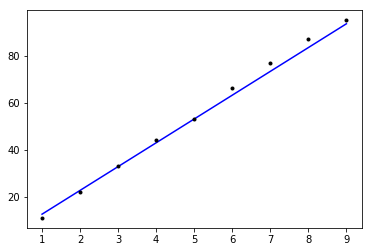

```python
import matplotlib.pyplot as plt
plt.plot(X, model.predict(X), 'b', X,y, 'k.')
```

model.predict()은 학습이 완료된 모델이 입력된 데이터에 대해서 어떤 값을 예측하는지를 보여줍니다.

```python
print(model.predict([9.5]))
```

```
[[98.55647]]
```

9시간 30분을 공부하면 약 98.5점을 얻는다고 예측하고 있습니다.

## 4. 로지스틱 회귀(Logistic Regression) - 이진 분류

### 1) 이진 분류(Binary Classification)

[figure not shown]

실제값 y가 0 또는 1이라는 두 가지 값밖에 가지지 않는데, 이 문제를 풀기 위해서는 예측값이 0과 1사이의 값을 가지도록 하는 것이 보편적입니다.

0과 1사이의 값을 가지면서, S자 형태로 그려지는 이러한 조건을 충족하는 유명한 함수가 존재하는데, 바로 시그모이드 함수(Sigmoid function)입니다.

### 2) 시그모이드 함수(Sigmoid function)

$H(X) = \frac{1}{1 + e^{-(Wx + b)}} = sigmoid(Wx + b) = σ(Wx + b)$

여기서 구해야할 것은 여전히 주어진 데이터에 가장 적합한 가중치 W(weight)와 편향 b(bias)입니다.

시그모이드 함수를 파이썬의 Matplotlib을 통해서 그래프로 표현하면 다음과 같습니다. 아래의 그래프는 W는 1, b는 0임을 가정한 그래프입니다.

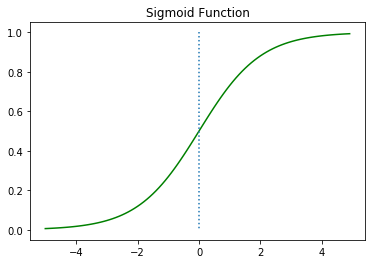

```python
import numpy as np # 넘파이 사용
import matplotlib.pyplot as plt # 맷플롯립 사용

def sigmoid(x):
    return 1/(1+np.exp(-x))
x = np.arange(-5.0, 5.0, 0.1)
y = sigmoid(x)

plt.plot(x, y, 'g')
plt.plot([0,0],[1.0,0.0], ':') # 가운데 점선 추가
plt.title('Sigmoid Function')
plt.show()
```

우선 W의 값을 변화시키고 이에 따른 그래프를 확인해보겠습니다.

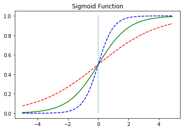

```python
import numpy as np # 넘파이 사용
import matplotlib.pyplot as plt # 맷플롯립 사용

def sigmoid(x):
    return 1/(1+np.exp(-x))
x = np.arange(-5.0, 5.0, 0.1)
y1 = sigmoid(0.5*x)
y2 = sigmoid(x)
y3 = sigmoid(2*x)

plt.plot(x, y1, 'r', linestyle='--') # W의 값이 0.5일때
plt.plot(x, y2, 'g') # W의 값이 1일때
plt.plot(x, y3, 'b', linestyle='--') # W의 값이 2일때
plt.plot([0,0],[1.0,0.0], ':') # 가운데 점선 추가
plt.title('Sigmoid Function')
plt.show()
```

위의 그래프는 W의 값이 0.5일때 빨간색선, W의 값이 1일때는 초록색선, W의 값이 2일때 파란색선이 나오도록 하였습니다.

앞서 선형 회귀에서 가중치 W는 직선의 기울기를 의미했지만, 여기서는 그래프의 경사도를 결정합니다.

이제 b의 값에 따라서 그래프가 어떻게 변하는지 확인해보도록 하겠습니다.

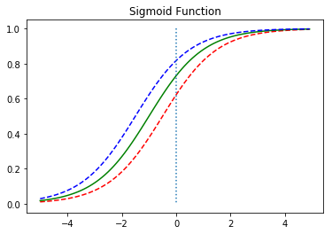

```python
import numpy as np # 넘파이 사용
import matplotlib.pyplot as plt # 맷플롯립 사용

def sigmoid(x):
    return 1/(1+np.exp(-x))
x = np.arange(-5.0, 5.0, 0.1)
y1 = sigmoid(x+0.5)
y2 = sigmoid(x+1)
y3 = sigmoid(x+1.5)

plt.plot(x, y1, 'r', linestyle='--') # x + 0.5
plt.plot(x, y2, 'g') # x + 1
plt.plot(x, y3, 'b', linestyle='--') # x + 1.5
plt.plot([0,0],[1.0,0.0], ':') # 가운데 점선 추가
plt.title('Sigmoid Function')
plt.show()
```

위의 그래프는 b의 값에 따라서 그래프가 이동하는 것을 보여줍니다.

시그모이드 함수는 입력값이 커지면 1에 수렴하고, 입력값이 작아지면 0에 수렴합니다. 0부터의 1까지의 값을 가지는데 출력값이 0.5 이상이면 1(True), 0.5이하면 0(False)로 만들면 이진 분류 문제로 사용할 수 있습니다.

이를 확률이라고 생각하면 해당 범주에 속할 확률이 50%가 넘으면, 해당 범주라고 판단하고 50%보다 낮으면 아니라고 판단한다고도 볼 수 있습니다.

### 3) 비용 함수(Cost function)

로지스틱 회귀 또한 경사 하강법을 사용하여 가중치 W를 찾아내지만, 비용 함수로는 평균 제곱 오차를 사용하지 않습니다.

그 이유는 시그모이드 함수에 비용 함수를 평균 제곱 오차로 하여 그래프를 그리면 다음과 같이 되기 때문입니다.

[figure not shown]

로지스틱 회귀에서 평균 제곱 오차를 비용 함수로 사용하면, 경사 하강법을 사용하였을때 자칫 잘못하면 찾고자 하는 최소값이 아닌 잘못된 최소값에 빠집니다.

이를 전체 함수에 걸쳐 최소값인 글로벌 미니멈(Global Minimum)이 아닌 특정 구역에서의 최소값인 로컬 미니멈(Local Minimum)에 도달했다고 합니다. 이는 cost가 최소가 되는 가중치 W를 찾는다는 비용 함수의 목적에 맞지 않습니다.

그렇다면 가중치 W를 최소로 만드는 새로운 비용 함수를 찾아야 합니다. 가중치를 최소화하는 아래의 어떤 함수를 목적 함수라고 합시다.

비용 함수와 목적 함수를 최적의 가중치를 찾기 위해 함수의 값을 최소화하는 함수라는 의미에서 같은 의미의 용어로 사용합니다.

J는 목적 함수(objective function)를 의미합니다.

$J(W) = \frac{1}{n} \sum_{i=1}^{n} f\left(H(X_{i}), y_{i})\right)$

여기서 이 f는 비용 함수(cost function)라고 하겠습니다.

$J(W) = \frac{1}{n} \sum_{i=1}^{n} cost\left(H(X_{i}), y_{i})\right)$

시그모이드 함수는 0과 1사이의 y값을 반환합니다. 이는 실제값이 0일 때 y값이 1에 가까워지면 오차가 커지며 실제값이 1일 때 y값이 0에 가까워지면 오차가 커짐을 의미합니다. 그리고 이를 반영할 수 있는 함수는 로그 함수를 통해 표현이 가능합니다.

$\text{if } y=1 → \text{cost}\left( H(X), y \right) = -\log(H(X))$  
$\text{if } y=0 → \text{cost}\left( H(X), y \right) = -\log(1-H(x))$

위의 두 식을 그래프 상으로 표현하면 아래와 같습니다.

[figure not shown]

실제값이 1일 때의 그래프를 파란색 선으로 표현하였으며, 실제값이 0일 때의 그래프를 빨간색 선으로 표현하였습니다.

위의 그래프를 간략히 설명하면, 실제값이 1일 때, 예측값인 H(X)의 값이 1이면 오차가 0이므로 당연히 cost는 0이 됩니다. 반면, 실제값이 1일 때, H(X)가 0으로 수렴하면 cost는 무한대로 발산합니다.

실제값이 0인 경우는 그 반대로 이해하면 됩니다. 이는 다음과 같이 하나의 식으로 표현할 수 있습니다.

$\text{cost}\left( H(X), y \right) = -[ylogH(X) + (1-y)log(1-H(X))]$

결과적으로 로지스틱 회귀의 목적 함수는 아래와 같습니다.

$J(W) = -\frac{1}{n} \sum_{i=1}^{n} [y_{i}logH(X_{i}) + (1-y_{i})log(1-H(X_{i}))]$

이때 로지스틱 회귀에서 찾아낸 비용 함수를 크로스 엔트로피(Cross Entropy)함수라고 합니다.

즉, 결론적으로 로지스틱 회귀는 비용 함수로 크로스 엔트로피 함수를 사용하며, 가중치를 찾기 위해서 크로스 엔트로피 함수의 평균을 취한 함수를 사용합니다.

### 4) 케라스로 구현하는 로지스틱 회귀

```python
from keras.models import Sequential # 케라스의 Sequential()을 임포트
from keras.layers import Dense # 케라스의 Dense()를 임포트
from keras import optimizers # 케라스의 옵티마이저를 임포트
import numpy as np # Numpy를 임포트

X=np.array([-50, -40, -30, -20, -10, -5, 0, 5, 10, 20, 30, 40, 50])
y=np.array([0, 0, 0, 0, 0, 0, 0, 0, 1, 1, 1, 1, 1]) #숫자 10부터 1

model=Sequential()
model.add(Dense(1, input_dim=1, activation='sigmoid'))
sgd=optimizers.SGD(lr=0.01)
model.compile(optimizer=sgd ,loss='binary_crossentropy',metrics=['binary_accuracy'])
# 옵티마이저는 경사하강법의 일종인 확률적 경사 하강법 sgd를 사용합니다.
# 손실 함수(Loss function)는 binary_crossentropy(이진 크로스 엔트로피)를 사용합니다.
model.fit(X,y, batch_size=1, epochs=200, shuffle=False)
# 주어진 X와 y데이터에 대해서 오차를 최소화하는 작업을 200번 시도합니다.
```

```
<keras.callbacks.History at 0x215e13272e8>
```

임의의 숫자들의 나열을 X라고 하였을 때, 숫자 10 이상인 경우에는 1, 미만인 경우에는 0을 부여한 레이블 데이터를 y라고 해봅시다.

단순 선형 회귀때와 마찬가지로 1개의 실수인 X로부터 1개의 실수인 y를 예측하는 맵핑 관계를 가지므로 각각 1을 기재합니다. 또한 시그모이드 함수를 사용할 것이므로 activation에 sigmoid를 기재해줍니다.

옵티마이저로는 경사 하강법의 일종인 확률적 경사 하강법을 사용하였으며, 손실 함수로는 크로스 엔트로피 함수를 사용합니다. 이진 분류 문제에 크로스 엔트로피 함수를 사용할 경우에는 binary_crossentropy를 기재해주면 됩니다. 전체 데이터에 대한 훈련 횟수는 200으로 합니다.

실제값과 오차를 최소화하는 W와 b의 값을 가진 시그모이드 함수 그래프를 그려보겠습니다.

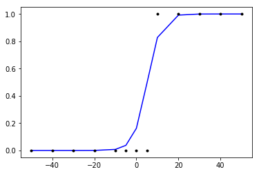

```python
import matplotlib.pyplot as plt
plt.plot(X, model.predict(X), 'b', X,y, 'k.')
```

이제 X값이 5보다 작은 값일 때와 X값이 10보다 클 때에 대해서 y값을 출력해봅시다.

```python
print(model.predict([1, 2, 3, 4, 4.5]))
print(model.predict([11, 21, 31, 41, 500]))
```

```
[[0.21112327]
 [0.26951855]
 [0.33716246]
 [0.4122035 ]
 [0.4515741 ]]
[[0.86907977]
 [0.9939634 ]
 [0.9997552 ]
 [0.9999901 ]
 [1.        ]]
```

X값이 5보다 작을 때는 0.5보다 작은 값을, X값이 10보다 클 때는 0.5보다 큰 값을 출력하는 것을 볼 수 있습니다.

## 5. 다중 입력에 대한 실습

독립 변수 x가 2개 이상인 선형 회귀와 로지스틱 회귀

### 1) 다중 선형 회귀

독립 변수가 2개 이상

입력 벡터의 차원이 2이상이라고 할 수 있습니다.

$H(X) = {W_1x_1 + W_2x_2 + W_3x_3 + b}$

y를 결정하는데 있어 독립 변수가 3개인 선형 회귀를 풀어봅시다. 중간 고사, 기말 고사, 그리고 추가 점수를 어떤 공식을 통해 최종 점수를 계산한 데이터가 있습니다.

데이터 중 상위 5개의 데이터만 훈련에 사용하고, 나머지 2개는 테스트에 사용해보겠습니다.

```python
from keras.models import Sequential # 케라스의 Sequential()을 임포트
from keras.layers import Dense # 케라스의 Dense()를 임포트
from keras import optimizers # 케라스의 옵티마이저를 임포트
import numpy as np # Numpy를 임포트

X=np.array([[70,85,11],[71,89,18],[50,80,20],[99,20,10],[50,10,10]]) # 중간, 기말, 가산점
# 입력 벡터의 차원은 3입니다. 즉, input_dim은 3입니다.
y=np.array([73,82,72,57,34]) # 최종 성적
# 출력 벡터의 차원은 1입니다. 즉, output_dim은 1입니다.

model=Sequential()
model.add(Dense(1, input_dim=3, activation='linear'))
sgd=optimizers.SGD(lr=0.00001)
# 학습률(learning rate, lr)은 0.01로 합니다.
model.compile(optimizer=sgd ,loss='mse',metrics=['mse'])
# 옵티마이저는 경사하강법의 변형인 확률적 경사 하강법 sgd를 사용합니다.
# 손실 함수(Loss function)은 평균제곱오차 mse를 사용합니다.
model.fit(X,y, batch_size=1, epochs=2000, shuffle=False)
# 주어진 X와 y데이터에 대해서 오차를 최소화하는 작업을 2,000번 시도합니다.
```

```
<keras.callbacks.History at 0x215e14c5550>
```

앞서 실습한 선형 회귀 코드와 거의 동일한데 달라진 점은 입력의 차원이 3으로 바뀌면서, input_dim의 인자값이 3으로 바뀌었다는 점입니다.

아직 오차(loss)가 줄어들 여지가 있지만, 여기서는 이 정도에서 예측 작업을 해보겠습니다.

```python
print(model.predict(X))
```

```
[[73.01625 ]
 [81.97073 ]
 [72.01715 ]
 [57.13904 ]
 [33.744396]]
```

이제 훈련할 때 사용하지 않았던 데이터를 가지고 예측 작업을 수행해보겠습니다.

```python
X_test=np.array([[20,99,10],[40,50,20]]) # 각각 58점과 56점을 예측해야 합니다.
print(model.predict(X_test))
```

```
[[57.958828]
 [55.91542 ]]
```

### 2) 다중 로지스틱 회귀

y 를 결정하는데 있어 독립 변수 x가 2개인 로지스틱 회귀를 풀어봅시다.

이 경우 가설은 다음과 같습니다.

$H(X) = sigmoid({W_1x_1 + W_2x_2 + b})$

OR 게이트는 0 또는 1의 값을 입력으로 받는데, 두 개의 입력 x1, x2 중 하나라도 1이면 출력값 y가 1이 되고 두 개의 입력이 0인 경우에만 출력값이 0이 되는 게이트입니다. 로지스틱 회귀를 통해 OR 게이트를 구현해봅시다.

```python
import numpy as np
X=np.array([[0, 0], [0, 1], [1, 0], [1, 1]])
# 입력 벡터의 차원은 2입니다. 즉, input_dim은 2입니다.
y=np.array([0, 1, 1, 1])
# 출력 벡터의 차원은 1입니다. 즉, output_dim은 1입니다.
```

```python
from keras.models import Sequential # 케라스의 Sequential()을 임포트
from keras.layers import Dense # 케라스의 Dense()를 임포트
from keras import optimizers # 케라스의 옵티마이저를 임포트


model=Sequential()
model.add(Dense(1, input_dim=2, activation='sigmoid')) # 이제 입력의 차원은 2입니다.
model.compile(optimizer='sgd' ,loss='binary_crossentropy',metrics=['binary_accuracy'])
# 옵티마이저는 경사하강법의 변형인 확률적 경사 하강법 sgd를 사용합니다.
# 손실 함수(Loss function)는 binary_crossentropy(이진 크로스 엔트로피)를 사용합니다.
model.fit(X,y, batch_size=1, epochs=800, shuffle=False)
# 주어진 X와 y데이터에 대해서 오차를 최소화하는 작업을 800번 시도합니다.
```

```
<keras.callbacks.History at 0x215e28a6470>
```

앞서 실습한 로지스틱 회귀 코드와 거의 동일한데 달라진 점은 입력의 차원이 2로 바뀌면서, input_dim의 인자값이 2로 바뀌었다는 점입니다.

```python
print(model.predict(X))
```

```
[[0.35163167]
 [0.8766777 ]
 [0.8701636 ]
 [0.9887449 ]]
```

입력이 둘 다 0, 0인 경우를 제외하고 나머지 3개의 입력 쌍(pair)에 대해서는 전부 값이 0.5를 넘는 것을 볼 수 있습니다.

### 3) 인공 신경망 다이어그램

다중 로지스틱 회귀를 뒤에서 배우게 되는 인공 신경망의 형태로 표현하면 다음과 같습니다. 아직 인공 신경망을 배우지 않았음에도 이렇게 다이어그램으로 표현해보는 이유는 로지스틱 회귀를 일종의 인공 신경망 구조로 해석해도 무방함을 보여주기 위함입니다.

$y = sigmoid(W_1x_1 + W_2x_2 + W_3x_3 + ... + W_nx_n + b) = σ(W_1x_1 + W_2x_2 + W_3x_3 + ... + W_nx_n + b)$

[figure not shown]

## 6. 벡터와 행렬 연산

다음 챕터의 소프트맥스 회귀에서는 종속 변수 y의 종류도 3개 이상이 되면서 더욱 복잡해집니다. 그리고 여기서 이러한 식들이 겹겹이 누적되는 층(layer) 개념까지 들어가기 시작하면 인공 신경망의 개념이 됩니다.

문제로부터 사용자가 데이터와 변수의 개수로부터 행렬의 크기, 더 나아가서는 텐서의 크기를 산정할 수 있어야 합니다.

인공 신경망의 각종 모델들에서 벡터와 행렬에 대한 개념이 지속적으로 등장하므로 이를 이해하고 있어야 합니다.

### 1) 벡터와 행렬과 텐서

1. 벡터

벡터는 크기와 방향을 가진 양입니다.

숫자가 나열된 형상이며 파이썬에서는 1차원 배열 또는 리스트로 표현합니다.

1. 행렬

행렬은 행과 열을 가지는 2차원 형상을 가진 구조입니다.

파이썬에서는 2차원 배열로 표현합니다.

1. 텐서

3차원부터는 주로 텐서라고 부릅니다.

텐서는 파이썬에서는 3차원 이상의 배열로 표현합니다.

### 2) 텐서(Tensor)

인공 신경망은 복잡한 모델 내의 연산을 주로 행렬 연산을 통해 해결합니다.

머신 러닝의 입, 출력이 복잡해지면 3차원 텐서에 대한 이해가 필수로 요구됩니다.

텐서를 설명하기 위한 아래의 모든 코드는 Numpy를 임포트했다고 가정합니다.

```python
import numpy as np
```

#### (1) 0차원 텐서

스칼라는 하나의 실수값으로 이루어진 데이터를 말합니다.

또한 스칼라값을 0차원 텐서라고 합니다. 차원을 영어로 Dimensionality라고 하므로 0D 텐서라고도 합니다.

```python
d=np.array(5)
print(d.ndim) # 차원수 출력
print(d.shape) # 텐서의 크기 출력
```

```
0
()
```

Numpy의 ndim은 축의 개수를 출력하는데, 이는 텐서에서의 차원수와 동일합니다.

#### (2) 1차원 텐서

숫자를 특정 순서대로 배열한 것을 벡터라고합니다. 또한 벡터를 1차원 텐서라고 합니다.

주의할 점은 벡터의 차원과 텐서의 차원은 다른 개념이라는 점입니다. 아래의 예제는 4차원 벡터이지만, 1차원 텐서입니다. 1D 텐서라고도 합니다.

```python
d=np.array([1, 2, 3, 4])
print(d.ndim)
print(d.shape)
```

```
1
(4,)
```

벡터의 차원과 텐서의 차원의 정의로 인해 혼동할 수 있는데 벡터에서의 차원(Dimensionality)은 하나의 축에 차원들이 존재하는 것이고, 텐서에서의 차원(Dimensionality)은 축의 개수를 의미합니다.

#### (3) 2차원 텐서

행과 열이 존재하는 벡터의 배열. 즉, 행렬(matrix)을 2차원 텐서라고 합니다. 2D 텐서라고도 합니다.

```python
d=np.array([[1, 2, 3, 4], [5, 6, 7, 8], [9, 10, 11, 12]])
print(d.ndim)
print(d.shape)
```

```
2
(3, 4)
```

#### (4) 3차원 텐서

행렬 또는 2차원 텐서를 단위로 한 번 더 배열하면 3차원 텐서라고 부릅니다. 3D 텐서라고도 합니다.

사실 위에서 언급한 0차원 ~ 2차원 텐서는 각각 스칼라, 벡터, 행렬이라고 해도 무방하므로 3차원 이상의 텐서부터 본격적으로 텐서라고 부릅니다.

조금 쉽게 말하면 데이터 사이언스 분야 한정으로 주로 3차원 이상의 배열을 텐서라고 부릅니다.

```python
d=np.array([
            [[1, 2, 3, 4, 5], [6, 7, 8, 9, 10], [10, 11, 12, 13, 14]],
            [[15, 16, 17, 18, 19], [19, 20, 21, 22, 23], [23, 24, 25, 26, 27]]
            ])
print(d.ndim)
print(d.shape)
```

```
3
(2, 3, 5)
```

2개의 큰 데이터가 있는데, 그 각각은 3개의 더 작은 데이터로 구성되며, 그 3개의 데이터는 또한 더 작은 5개의 데이터로 구성되어져 있습니다.

자연어 처리에서 특히 자주 보게 되는 것이 이 3D 텐서입니다.

이 경우 3D 텐서는 (samples, timesteps, word_dim)이 됩니다. 또는 일괄로 처리하기 위해 데이터를 묶는 단위인 배치의 개념에 대해서 뒤에서 배울텐데 (batch_size, timesteps, word_dim)이라고도 볼 수 있습니다.

samples/batch_size는 데이터의 개수, timesteps는 시퀀스의 길이, word_dim은 단어를 표현하는 벡터의 차원을 의미합니다.

자연어 처리에서 왜 3D 텐서의 개념이 사용되는지 간단한 예를 들어봅시다.

- 문서1 : I like NLP
- 문서2 : I like DL
- 문서3 : DL is AI

인공 신경망의 모델의 입력으로 사용하기 위해서는 각 단어를 벡터화해야 합니다.

단어를 벡터화하는 방법으로는 원-핫 인코딩이나 워드 임베딩이라는 방법이 대표적이나 워드 임베딩은 아직 배우지 않았으므로 원-핫 인코딩으로 모든 단어를 벡터화 해보겠습니다.

| 단어 | One-hot vector |
| --- | --- |
| I | [1 0 0 0 0 0] |
| like | [0 1 0 0 0 0] |
| NLP | [0 0 1 0 0 0] |
| DL | [0 0 0 1 0 0] |
| is | [0 0 0 0 1 0] |
| AI | [0 0 0 0 0 1] |

원-핫 벡터로 바꿔서 인공 신경망의 입력으로 한 꺼번에 사용한다고 하면 다음과 같습니다. (이렇게 훈련 데이터를 여러개 묶어서 한 꺼번에 입력으로 사용하는 것을 배치(Batch)라고 합니다.)

[[[1, 0, 0, 0, 0, 0], [0, 1, 0, 0, 0, 0], [0, 0, 1, 0, 0, 0]],  
[[1, 0, 0, 0, 0, 0], [0, 1, 0, 0, 0, 0], [0, 0, 0, 1, 0, 0]],  
[[0, 0, 0, 1, 0, 0], [0, 0, 0, 0, 1, 0], [0, 0, 0, 0, 0, 1]]]

이는 (3, 3, 6)의 크기를 가지는 3D 텐서입니다.

#### (5) 그 이상의 텐서

3차원 텐서를 배열로 합치면 4차원 텐서가 됩니다. 4차원 텐서를 배열로 합치면 5차원 텐서가 됩니다. 이런 식으로 텐서는 배열로서 계속해서 확장될 수 있습니다.

[figure not shown]

위의 그림은 각 텐서를 도형으로 시각화한 모습을 보여줍니다.

#### (6) 케라스에서의 텐서

케라스에서는 입력의 크기(shape)를 인자로 줄 때 input_shape라는 인자를 사용합니다.

input_shape는 배치 크기를 제외하고 차원을 지정하는데,  
예를 들어 input_shape(6, 5)라는 인자값을 사용하고 배치 크기를 32라고 지정한다면 이 텐서의 크기는 (32, 6, 5)을 의미합니다.

만약 배치 크기까지 지정해주고 싶다면 batch_input_shape=(8, 2, 10)와 같이 인자를 주면 이 텐서의 크기는 (8, 2, 10)을 의미합니다.

그 외에도 입력의 속성 수를 의미하는 input_dim, 시퀀스 데이터의 길이를 의미하는 input_length 등의 인자도 사용합니다. 사실 input_shape의 두 개의 인자는 (input_length, input_dim)라고 볼 수 있습니다.